# Introduction to Hidden Markov Models

Jared Stabach, Smithsonian’s National Zoo & Conservation Biology Institute

06 August 2025

# Introduction

> Many thanks to Dr. Joseph Kolowski for assistance in developing this material

There are two main packages for fitting discrete-time hidden Markov models (HMMs) in [R](https://cran.r-project.org/): [moveHMM](https://cran.r-project.org/web/packages/moveHMM/index.html) and [momentuHMM](https://cran.r-project.org/web/packages/momentuHMM/index.html). These packages are very similar (i.e., the syntax is the same) and both packages are maintained by the same architects, Theo Michelot and Brett McClintock. The difference between the two packages is the complexity of models that can be fitted, with [moveHMM](https://cran.r-project.org/web/packages/moveHMM/index.html) limited to estimating 2 or so biologically-meaningful behavior states from the data stream (i.e,. step length, turning angle). [MomentuHMM](https://cran.r-project.org/web/packages/momentuHMM/index.html), however, allows for the incorporation of auxiliary biotelemetry information (e.g., from pressure, conductivity, heart rate, or motion sensors), which results in less restrictions on the constraints to parameters and provides for greater possibilities in estimating additional behavioral states.

In this exercise, we will fit HMMs with the [momentuHMM](https://cran.r-project.org/web/packages/momentuHMM/index.html) package to assess changes in wildebeest behavior. We will continue to use the dataset from previous exercises that has been cleaned and subset to the Athi-Kaputiei Plains in Kenya. Remember that the data have been re-sampled to a 3-hour fix interval. We’ll investigate the role of temperature and time of day on the movement behaviors of wildebeest, but many other environmental variables (e.g., Anthropogenic Disturbance) could be added to further our understanding on potential impacts to animals.

Code is based on exercises developed by Joe Kolowski at the Smithsonian-Mason School of Conservation, with sections modified from the [momentuHMM](https://cran.r-project.org/web/packages/momentuHMM/index.html) guide.

In this exercise, we will:

- Learn the analysis workflow for fitting hidden Markov models with [momentuHMM](https://cran.r-project.org/web/packages/momentuHMM/index.html)
- Practice investigation of impact of continuous covariates on state transition probabilities
- Learn how to interpret the output from HMMs
- Practice methods for visualizing HMM output both spatially and graphically
- Use model output to subset tracking datasets

## Load Libraries

Load the required libraries and remove everything held in [R’s](https://cran.r-project.org/) memory.

```r
# Remove items from memory/clean your workspace
rm(list=ls())

# You may need to install these packages first
#install.packages('momentuHMM', 'lubridate', 'tidyverse')

# Load libraries
library(momentuHMM)
library(lubridate)
library(tidyverse)
```

## Data Import & Formatting

Load the cleaned wildebeest dataset from the previous exercise. Before doing so, there are a few things to note:

- Data for analysis should have negligible location error. If you are working with high levels of error (common to marine species that are being tracked by Argos) or if data are irregular, you should likely process it first before analysis. For example, you may try a state space approach, such as [crawl](https://cran.r-project.org/web/packages/crawl/index.html) or [aniMotum](https://ianjonsen.github.io/aniMotum/articles/Overview.html), or use [ctmm](https://cran.r-project.org/web/packages/ctmm/index.html) to correct for the GPS error and then use `predict()` to create the most likely path of your animal for incorporation in analysis. [MomentuHMM](https://cran.r-project.org/web/packages/momentuHMM/index.html) also provides a 2-stage imputation approach when data are temporarily-irregular or subject to measurement error. See the `help()` for more information.
- Data should be analyzed in an ordered sequence (Neither [moveHMM](https://cran.r-project.org/web/packages/moveHMM/index.html) or [momentuHMM](https://cran.r-project.org/web/packages/momentuHMM/index.html) recognizes the time as a sequence. Use `arrange()` to order by the time field.
- The animal id column must be named “ID”.
- When analyzing the data as UTMs, converting the coordinates to km by dividing by 1000 is helpful in estimating model parameters.

```r
# Read the dataset into R, selecting the necessary columns (x, y, date, id) for analyses.
# We will also grab the temperature column and the sex of each animal and convert the x/y values to km (e.g., x/1000).
# We'll also create an hour field from the timestamp and make sex a numeric variable using the mutate() function.

# Data load/import
load("Data/wildebeest_3hr_data.rdata")

# Process the movement dataset.  We'll use the dataset created from adehabitat
WB.data <- WB.move %>%
  arrange(id, date) %>% # Not necessary here, but good practice
  select(x,
         y,
         t = date,
         ID = id,
         temp,
         sex) %>%
  mutate(hour = hour(t),
         x = x/1000,
         y = y/1000,
         sex = as.numeric(sex))
```

# Create Move Object

Now that we have imported the data, we will use the function `prepData` to prepare the data for analyses and create a `momenuHMMData` object. If our data were provided as raw lat/long values, we could still import the data, but we would need to set the type = “LL” (default). We can specify the coordinate and covariate names explicity. See `help(prepData)` for additional information.

**Note** [MomentuHMM](https://cran.r-project.org/web/packages/momentuHMM/index.html) package only works with longitude/latitude and UTM projected data.

```r
# Create Object
WB.move <- WB.data  %>%
  prepData(type = "UTM",
           # Specify coordinate names
           coordNames = c("x","y"), # Note the order: x, y
           covNames = c("temp", "sex", "hour"))

# What's the class of the object?
class(WB.move)
```

```
## [1] "momentuHMMData" "data.frame"
```

## Object Summary

The [MomentuHMM](https://cran.r-project.org/web/packages/momentuHMM/index.html) package includes a number of functions to help summarize the content of the `momentuHMMData` object. We’ll see that we have movement data for all 12 wildebeest (a good check!). We also see from above that the format is a data.frame, making it relatively easy to modify our object if we need to. Also notice that the function `prepData` created two additional columns in our dataset, “step (steplength)” and “angle (turning angle)”. These are the two fields that will be used in all future modeling steps. The plot function will show the movement trajectory and include plots of the steplengths and turning angles.

```r
# Summarize the object
summary(WB.move)
```

```
## HMM data for 12 individuals:
##
## Karbolo -- 3324 observations
## Kikaya -- 5820 observations
## Kiranto -- 6234 observations
## Laingoni -- 4152 observations
## Ne Mpaash -- 3813 observations
## Noontare -- 6226 observations
## Ntishya -- 6106 observations
## Ole Nagol -- 555 observations
## Paita -- 5851 observations
## Peria -- 6212 observations
## Sawani -- 1891 observations
## Sotua -- 2663 observations
##
##
## Data summaries:
##
##       step           angle
##  Min.   : 0.00   Min.   :-3.142
##  1st Qu.: 0.12   1st Qu.:-1.585
##  Median : 0.24   Median : 0.002
##  Mean   : 0.43   Mean   :-0.002
##  3rd Qu.: 0.49   3rd Qu.: 1.571
##  Max.   :13.40   Max.   : 3.142
##  NA's   :3539    NA's   :4024
```

```r
# What are the column headings included in this move object?
names(WB.move)
```

```
## [1] "ID"    "step"  "angle" "t"     "x"     "y"     "temp"  "sex"   "hour"
```

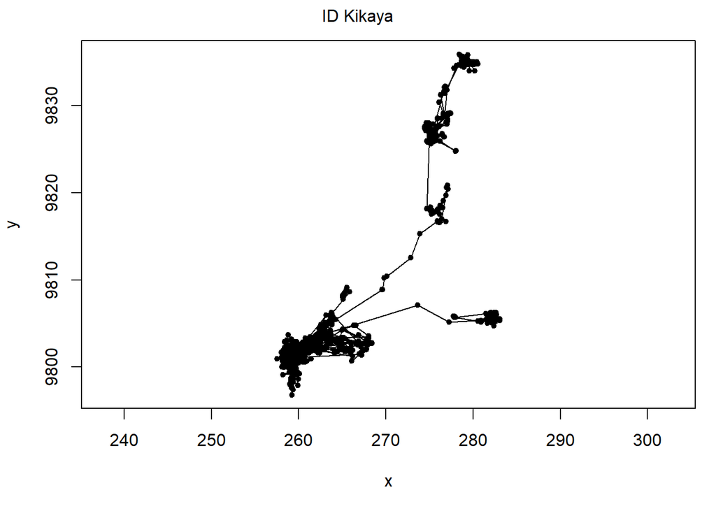

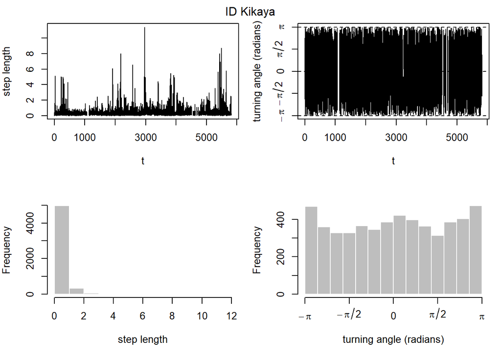

```r
# We can plot all animals together.  Please try!
# plot(WB.move,
#      compact = TRUE, # Make sure you specify compact = TRUE.  If you don't specify, each plot will be drawn separately, which can be tedious
#      ask = FALSE)

# Or, each animal separately
# unique(WB.move$ID) # We can always query the dataframe for the names of each animal.
plot(WB.move[WB.move$ID == "Kikaya",],
     ask = FALSE)
```

```r
# We can also investigate the steplength and turning separately, using standard R commands
# Note, however, the way these are writtent, they are summarizing all animals together
# hist(WB.move$step)
# summary(WB.move$step)
# quantile(WB.move$step,
#          probs = 0.90,
#          na.rm = TRUE)
# hist(WB.move$angle)
```

# Fitting a Hidden Markov Model

To begin modeling, we need to set starting values for all relevant estimable parameters. This is arguably the most challenging aspect of fitting a HMM. [MomentuHMM](https://cran.r-project.org/web/packages/momentuHMM/index.html) includes a number of functions, including `GetPar`, `getPar0`, `getParDM`, and `checkPar0`, to help with specification of starting values. See the `help()` for tips and tricks. Investigating the movements of your animals and being clear about the behaviors of interest (as opposed to simply data mining) will help with informing what these starting values should be.

As a starting point, we will fit a 2-state model, without specifying covariates to influence behavioral transitions (i.e., a NULL model). We will then build a few, slightly more complex models where the covariate(s) inform the transition from one state to the next.

First, we must specify the number of behavioral states we want to identify, which require us to provide initial values for the vectors stepPar0 (for the step distributions) and anglePar0 (for the angle distributions). We then need to select a statistical distribution that best describe each of these vectors.

[MomentuHMM](https://cran.r-project.org/web/packages/momentuHMM/index.html) includes a variety of distributions. We will use the gamma distribution to describe steplengths and the von Mises distribution for turning angles. Many other common distributions for steplength and turning angle can also be incorporated to find the best fitting model.

## Set Starting Values

The “gamma” distribution requires us to set two (and potentially three) parameters describing the steplengths of our animals: mean and standard deviation. The third potential parameter, called zero mass, is required if we have steplengths that are exactly zero. This parameter accounts for zero inflation in the gamma distribution - a strictly positive distribution. The “von Mises (vm)” distribution requires us to set two parameters describing the turning angles. These are the mean turning angle and the angle concentration, which reflects the variance in the turning angle distribution.

Here, we will choose initial values that correspond to commonly observed patterns in 2-state HMMs for animal movement data, with state 1 involving relatively short steps and many turns (small mean steplength and large mean turning angle - Slow tortuous movements) and state 2 involving longer steps and fewer turns (large mean steplength and small mean turning angle - Fast directory Movements). For ungulates, this is often referred to as an “area restricted search”, with animals switching from an “encamped” behavioral state to an “exploratory” behavioral state. Once again, this is a good opportunity to look at the movements of your data to identify items of interest that we might be able to identify in the data.

**Note:** To ensure starting values do not overly impact results, some authors will repeat model fitting with a range of starting values. This allows one to test the sensitivity of results to starting value decisions.

```r
# Check distributions
# hist(WB.move$step) #Looks like gamma
# hist(WB.move$angle) #Looks pretty normal

# Define Starting Values
# ************************************
# For Step Length (gamma distribution): c(mean1, mean2, sd1, sd2)
stepPar0 <- c(0.1, 1, 0.1, 1)

# For Turning Angle (von mises distribution): c(mean1, mean2, concentration1, concentration2)
# In radians, pi, or 3.14 represents 180 degrees.
anglePar0 <- c(pi, 0, 1, 1)
```

## Model Fitting

We will now use the function `fitHMM` to fit our NULL model. We specify the properly formatted object, define the number of states, input our starting values, and identify our steplength and turning angle distributions. Since this is our NULL model, we assume that no covariates influence behavioral transitions between states. We specify the NULL using standard regression formula notation (i.e., ~ 1).

The model summary provides a detailed numeric output, including the mean steplength from each predicted state and the standard deviation. We see that state 1 has a much smaller steplength (~ 287m) than state 2 (~ 694m). For turning angle means, we see that the mean of state 2 is much closer to 0. This would indicate continued movement in roughly the same direction (i.e., directed movement). The mean turning angle for state 1 is closer to `pi`, indicating that the animal is moving in circles. Since we did not test a regression equation, we only have an intercept regression coefficient.

We are also provided with a matrix of predicted transitions, showing the average probability of transitioning from state 1 to state 2 (~3%) and vice versa. The diagonals (the probability of remaining in each state) of the transition matrix are also very high (~95%), fitting in with what we’d expect behaviorally. The resulting plots describe the distributions of steplengths and turning angles for our two states. Paths are colored based on the predicted state for each animal, which is very interesting.

```r
# Fit NULL model
WB.null <- fitHMM(data = WB.move,
                  nbStates = 2,
                  dist = list(step = "gamma", angle = "vm"), # Need to add these as a list
                  Par0 = list(step = stepPar0, angle = anglePar0), # Need to add these as a list
                  formula = ~ 1,
                  estAngleMean = list(angle=TRUE))

# Examing the 2-state model
WB.null
```

```
## Value of the maximum log-likelihood: -93573.76
##
##
## step parameters:
## ----------------
##        state 1   state 2
## mean 0.2869584 0.6938467
## sd   0.2510433 0.8377385
##
## angle parameters:
## -----------------
##                 state 1    state 2
## mean          2.9570947 -0.1852975
## concentration 0.1292599  0.1780061
##
## Regression coeffs for the transition probabilities:
## ---------------------------------------------------
##                1 -> 2    2 -> 1
## (Intercept) -3.465318 -2.835974
##
## Transition probability matrix:
## ------------------------------
##            state 1    state 2
## state 1 0.96968469 0.03031531
## state 2 0.05541088 0.94458912
##
## Initial distribution:
## ---------------------
##   state 1   state 2
## 0.4990483 0.5009517
```

## Plotting Results

Now that we have a fitted model, we can plot the results to visualize the state predictions displayed in different colors.

```
## Decoding state sequence... DONE
```

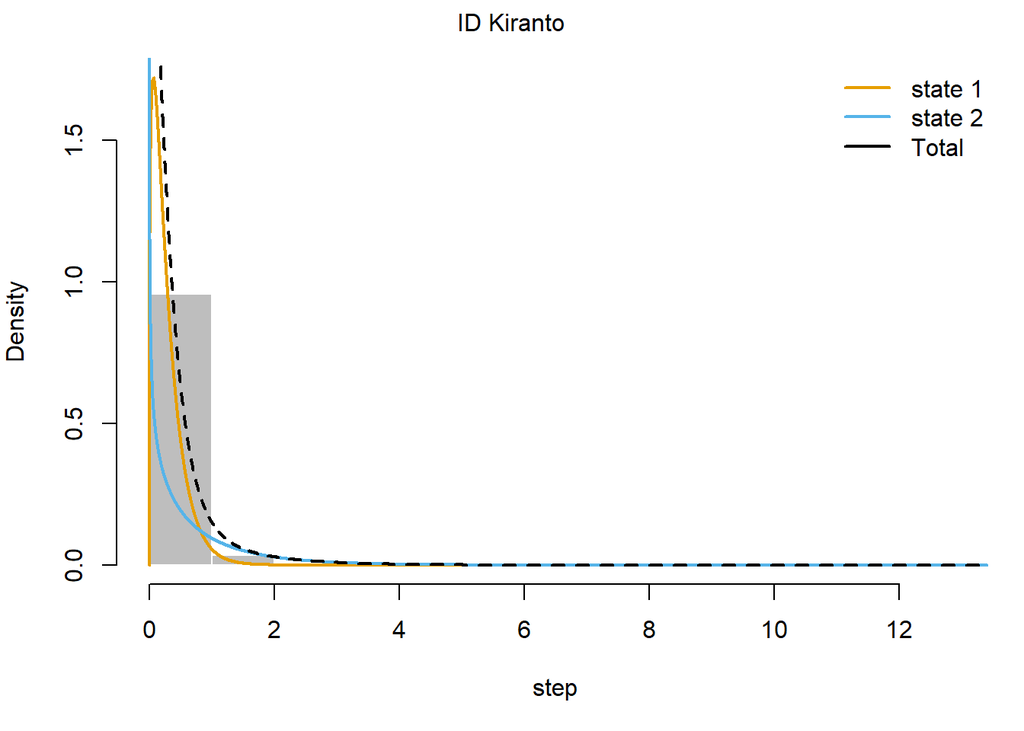

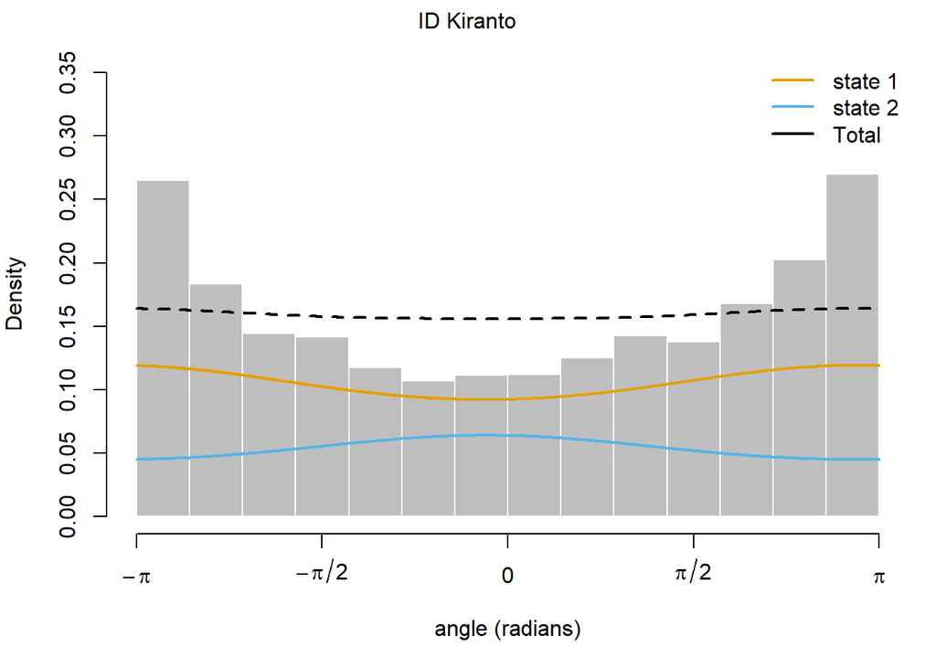

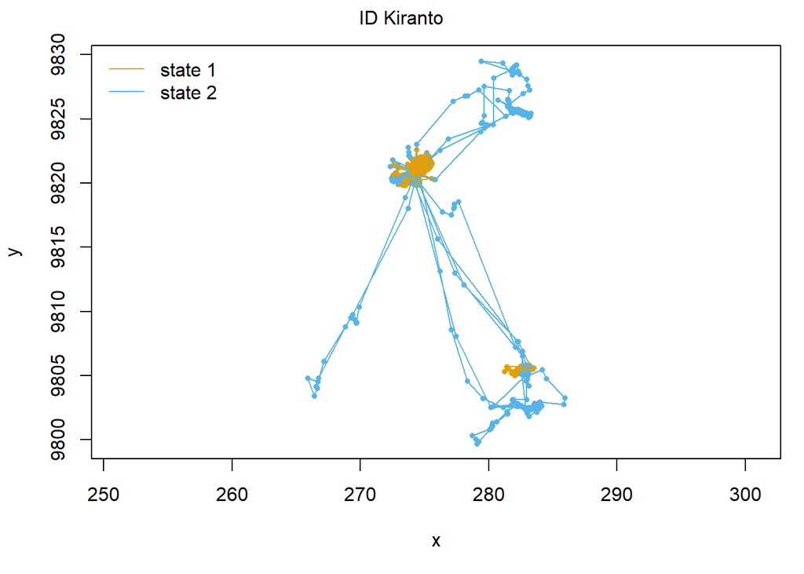

```r
# Plot the results of the predictions.
# Colored states (State 1 is orange; state 2 is blue) provide the predicted state in each trajectory.
# Plot all animals
# plot(WB.null,
#      ask = F)

# Plot individual animals
plot(WB.null,
     animals = "Kiranto",
     ask = FALSE)
```

## State Assignments & Probabilities

To decode the state processes identified, we will implement the Viterbi algorithm using the function `viterbi()` and compute state probabilities using the function `stateProbs()`. The Viterbi algorithm computes the sequence of most probable states to have generated the observations under the fitted model. State probabilities computes the probabilities of the underlying Markov chain being in different states at each observation under the fitted model. Both state assignments provide a predicted state for each location in our dataset, allowing us to look at (for example) the proportion of time spent in each state.

### Viterbi Algorithm

Results from using the Viterbi algorithm indicate that wildebeest spend about 66% of time in a resident/encamped movement state (state 1). We can look at these statistics for the population or for each individual and graphically display this information by linking the predicted state information to each position. These results are often a valuable first step and help a researcher think about other variables (e.g., season, breeding state) that could explain potential changes in behavior.

```r
# Run the algorithm on the fitted model
WB.states <- viterbi(WB.null)

# Look at the state assignments.  The result is just a simple vector of state assignments (class 1 or 2).
WB.states[1:25]
```

```
##  [1] 2 2 2 2 2 2 2 2 2 2 2 2 2 2 2 2 2 2 2 2 2 2 2 2 2
```

```r
# What's the proportion of time spent in each state?
prop.table(table(WB.states))
```

```
## WB.states
##         1         2
## 0.6610404 0.3389596
```

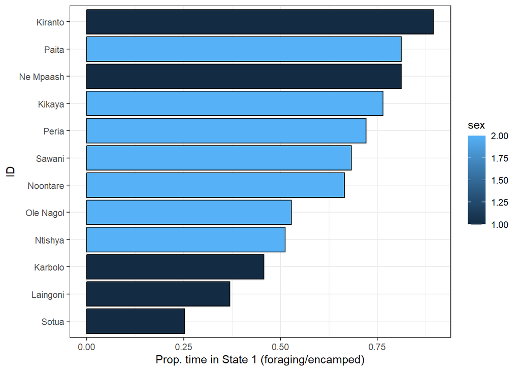

```r
# How does this differ between individuals?
# To answer this question, we need to combine the state assignments with the move object
WB.v.Props <- WB.move %>%
  # create state column
  mutate(state = WB.states) %>%

  # add new column that is the total locations for each animal...used to calculate percentages
  mutate(locs = n(),
         .by = ID) %>%

  # summarize for each animal, and each state, the proportion of locations.
  # Using reframe, as summarize has been deprecated in latest version of dplyr
  reframe(stateProp = n()/locs,
            sex = unique(sex),
            .by = c(ID, state)) %>%

  # This reduces our data frame from the same initial size, to one with just the unique rows of information.
  distinct() %>%
  arrange(ID, state)

# Graph results, color by sex to look for any potential patterns.  Just a graphical summary.
WB.v.Props %>%
  filter(state == 1) %>%
  mutate(ID = fct_reorder(ID,
                          stateProp)) %>%
  ggplot(aes(y = stateProp,
             x = ID,
             fill = sex)) +
  geom_col(col = "black",
           position = position_dodge()) +
  coord_flip() +
  labs(y = "Prop. time in State 1 (foraging/encamped)") +
  theme_bw()
```

```r
# Look at Kiranto
# plot(WB.move[WB.move$ID == "Kiranto",],
#      ask = FALSE)
# Interestingly, Kiranto made some long distance movements, although most of his time was spent in state 1

# How does his movement compare with Paita, for example?
# plot(WB.move[WB.move$ID == "Paita",],
#      ask = FALSE)
# A very different movement pattern, even though the amount of time in state 1 is very similar to Kiranto.
```

### State Probabilities

The `stateProbs()` function allows us to investigate the actual transitional probabilities between each point in the dataset. The output of the function is a matrix, with probabilities for each state. Values across rows should sum to 1. Note, the with highest probability according to `stateProbs()` might not be the same as the state in the most probable sequence returned by the `viterbi()` algorithm. This is because the Viterbi algorithm performs “global decoding”, whereas the state probabilities are “local decoding”. For more details, see Zucchini et al. (2016).

The `plotStats()` function will plot the most likely state sequence decoded by the Viterbi algorithm (top panel), as well as both columns of the matrix of state probabilities.

```
## Decoding state sequence... DONE
## Computing state probabilities... DONE
```

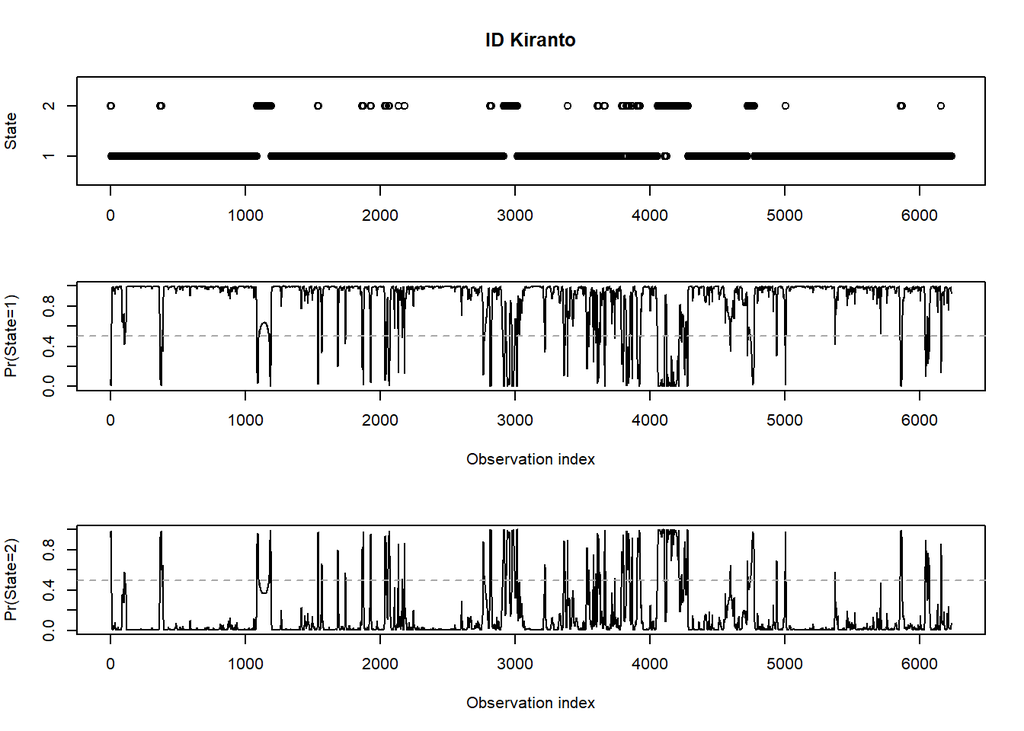

```r
# Calculate state probabilities
WB.probs <- stateProbs(WB.null)
# head(WB.probs)

# Visualize the state sequences for 1 animal
plotStates(WB.null,
          animals = "Kiranto",
          ask = FALSE)
```

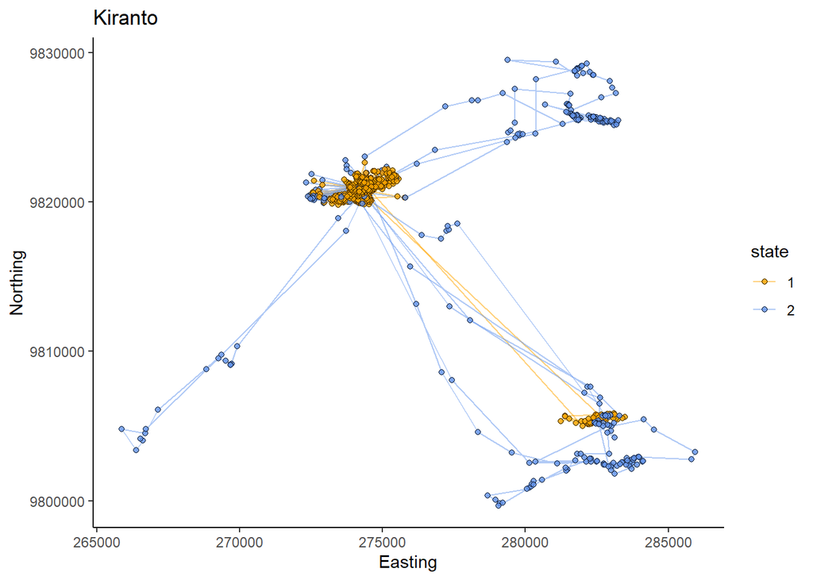

```r
# We can use the built-in plot functions (see help(plot.momentuHMM)) or create our own plots
WB.move %>%
  mutate(state = as.factor(WB.states)) %>%
  filter(ID == "Kiranto") %>%
  ggplot(aes(x = x*1000,
             y = y*1000,
             col = state,
             fill = state)) +
  geom_path(alpha = 0.5) +
  geom_point(shape = 21,
             alpha = 0.8,
             col = "black") +
  scale_fill_manual(values = c("orange",
                               "cornflowerblue")) +
  scale_color_manual(values = c("orange",
                                "cornflowerblue")) +
  theme_classic() +
  labs(x = "Easting",
       y = "Northing",
       title = "Kiranto")
```

# Model Comparison & Covariate Testing

## Covariate Model - Temperature

As a first example, we will fit a 2-state model with ambient temperature. We use the same starting values and parameter distributions specified previously in this script, but will add a formula `~ temp` with temperature as a covariate.

The resulting analyses indicate that the probability of being in state 1 (i.e., encamped/foraging) is very high when temperatures (degrees C) are low. As temperature increases, however, we see that the probability of being in state 1 starts to decrease. By the time we reach 40C, the state probability is about 50%.

```r
# Fit covariate model - temperature
WB.temp <- fitHMM(data = WB.move,
                  nbStates = 2,
                  dist = list(step = "gamma", angle = "vm"),
                  Par0 = list(step = stepPar0, angle = anglePar0),
                  formula = ~ temp,
                  estAngleMean = list(angle=TRUE))

# Show model summary
WB.temp
```

```
## Value of the maximum log-likelihood: -93571.99
##
##
## step parameters:
## ----------------
##        state 1   state 2
## mean 0.2871264 0.6933773
## sd   0.2511668 0.8374753
##
## angle parameters:
## -----------------
##                 state 1    state 2
## mean          2.9589406 -0.1828697
## concentration 0.1289938  0.1774131
##
## Regression coeffs for the transition probabilities:
## ---------------------------------------------------
##                  1 -> 2       2 -> 1
## (Intercept) -4.16451522 -2.649908954
## temp         0.02997581 -0.007944888
##
## Transition probability matrix (based on mean covariate values):
## ---------------------------------------------------------------
##            state 1   state 2
## state 1 0.96976720 0.0302328
## state 2 0.05548905 0.9445109
##
## Initial distribution:
## ---------------------
##   state 1   state 2
## 0.4964899 0.5035101
```

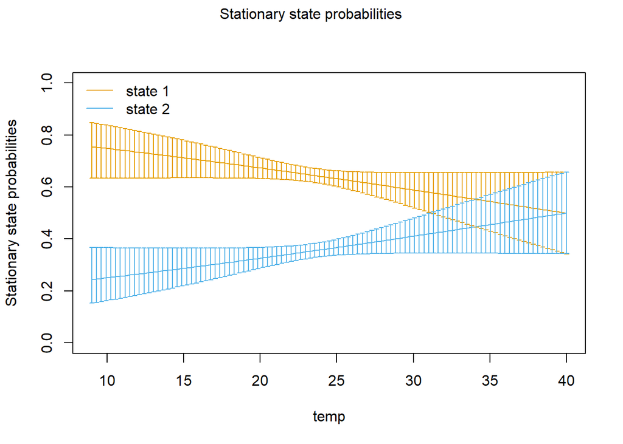

```r
# Built-in plotting function to evaluate the impacts of a covariate
plotStationary(WB.temp,
               plotCI = TRUE)
```

## Covariate Model - Time of Day

Now let’s test a model with time of day. Hour is a challenging variable to model in a regression equation. To include time, we need to use the special function `cosinor(hour, period = 24)` to internally create the cosinor model covariates, cos(2$\pi$ x hour/period) and sin(2$\pi$ x hour/period). We will use the same starting values included from the previous models.

```r
# Fit time covariate model
WB.tod.2state <- fitHMM(data = WB.move,
                 nbStates = 2,
                 dist = list(step = "gamma", angle = "vm"),
                 Par0 = list(step = stepPar0, angle = anglePar0),
                 formula = ~ cosinor(hour, period = 24),
                 estAngleMean = list(angle=TRUE))

# Summarize
WB.tod.2state
```

```
## Value of the maximum log-likelihood: -92827.27
##
##
## step parameters:
## ----------------
##        state 1   state 2
## mean 0.2295176 0.6949678
## sd   0.2159187 0.6915302
##
## angle parameters:
## -----------------
##                 state 1    state 2
## mean          3.0700690 -0.0412845
## concentration 0.1746631  0.1813962
##
## Regression coeffs for the transition probabilities:
## ---------------------------------------------------
##                                   1 -> 2    2 -> 1
## (Intercept)                   -29.147704 -27.75609
## cosinorCos(hour, period = 24)  -6.963346 -27.88149
## cosinorSin(hour, period = 24) -29.363320  12.29575
##
## Transition probability matrix (based on mean covariate values):
## ---------------------------------------------------------------
##           state 1      state 2
## state 1 1.0000000 1.807887e-15
## state 2 0.9375155 6.248446e-02
##
## Initial distribution:
## ---------------------
##   state 1   state 2
## 0.8290661 0.1709339
```

## Model Comparison

Now we’ll use AIC to evaluate which model is best fit to the data. Results indicate that the 2-state time of day model has the best statistical support. Other models, with more relevant predictors are likely to have greater support, but this at least provides a starting point for how to construct these types of models.

```r
# Create a data frame with model comparison metrics
model_comparison <- data.frame(
  Model = c("2-state Null", "2-state Temp", "2-state time"),
  AIC = c(AIC(WB.null), AIC(WB.temp), AIC(WB.tod.2state)))

# Print the model comparison table
print(model_comparison)
```

```
##          Model      AIC
## 1 2-state Null 187169.5
## 2 2-state Temp 187170.0
## 3 2-state time 185684.5
```

```r
# Identify the best model based on AIC
# Results indicate that the 2 state cosinor model is the best
best_model_aic <- model_comparison[which.min(model_comparison$AIC), "Model"]
paste("Best model based on AIC: ", best_model_aic, "model")
```

```
## [1] "Best model based on AIC:  2-state time model"
```

```r
# Plot the results
# plot(WB.tod.2state,
#      ask = FALSE)

# Plot an individual
# plot(WB.tod.2state,
#       animals = "Kiranto",
#       ask = FALSE)
```

# Further Applications

Similar to activities demonstrated above, we could encode the behavioral states identified to our original dataframe to our best fitting model. By doing so, we would be able to calculate how much time animals remain in particular behavioral states, compare differences in animal behavior between study areas, or identify areas that are associated with certain behavioral states. This could be particularly helpful if your goal was to separate the data to create seasonal home range where animals are mostly resident.

As an example, we’ll filter the data by state behaviors and plot each behavior separately. We’ll follow the same procedure that we demonstrated above. The output shows some clear areas where one of the wildebeest (Sawani) spent large periods in a encamped state, but there are quite a few points where these areas overlap (not clearly distinct). This is the kind of approach, however, that might work better for other species.

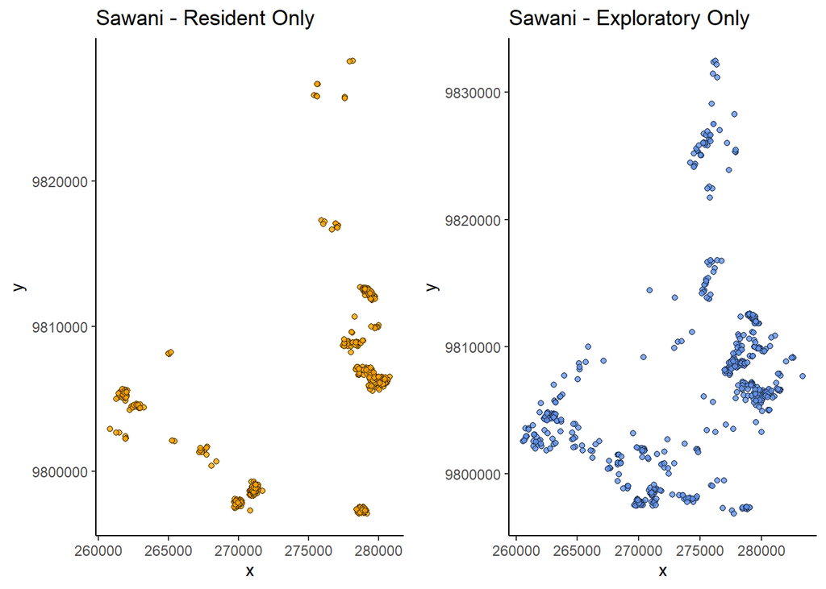

```r
# Encode the behaviors using the Viterbi algorithm
WB.tod.states <- viterbi(WB.tod.2state)

# add to the dataset and remove some extra fiels
WB.states <- WB.move %>%
  mutate(state = as.factor(WB.tod.states)) %>%
  # Remove some fields to make dataset smaller
  select(-c(step,angle,temp,hour))

# Create plot of Resident behaviors (State 1) for 1 individual
WB.State1 <- WB.states %>%
  filter(state == 1 & ID == "Sawani") %>%
  ggplot(aes(x = x*1000,
             y = y*1000,
             col = state,
             fill = state)) +
  #geom_path(alpha = 0.5) +
  geom_point(shape = 21,
             alpha = 0.8,
             col = "black",
             show.legend = FALSE) +
  scale_color_manual(values = "orange") +
  scale_fill_manual(values = "orange") +
  theme_classic() +
  labs(x = "x",
       y = "y",
       title = "Sawani - Resident Only")

# Create plot of exploratory behaviors (State 2) for 1 individual
WB.State2 <- WB.states %>%
  filter(state == 2 & ID == "Sawani") %>%
  ggplot(aes(x = x*1000,
             y = y*1000,
             col = state,
             fill = state)) +
  #geom_path(alpha = 0.5) +
  geom_point(shape = 21,
             alpha = 0.8,
             col = "black",
             show.legend = FALSE) +
  scale_color_manual(values = "cornflowerblue") +
  scale_fill_manual(values = "cornflowerblue") +
  theme_classic() +
  labs(x = "x",
       y = "y",
       title = "Sawani - Exploratory Only")

# Use the cowplot package to combine these plots next to each other.
two_plots <- cowplot::plot_grid(WB.State1,
                                WB.State2,
                                ncol = 2,
                                rel_widths = c(1, 1))

# Show the plots
two_plots
```

```r
# Save the plots
ggsave(plot = two_plots,
       filename = "Output/sawani_residencelocations.tiff",
       units = "in",
       width = 6.5,
       height = 4)
```

# Exercise:

In order to understand how HMMs work, it can be helpful to track yourself with an app downloaded on your phone (e.g., Geo Tracker). This way, you have a clear understanding of what you were doing (i.e., walking, eating, sleeping, running).

As an independent exercise, collect some data on yourself and record what you were doing. Download the data and create a workflow using [R](https://cran.r-project.org/). Import the data and fit a HMM to determine how well the model recovers the behaviors of your choosing. Are there any covariates that you might want to include to explain your behavioral changes? Try to keep this simple, with a few behaviors of interest to identify in your track (i.e., no more the 3 or 4).